# Fig_Andel_lite_fysakt_Ungdata

Steinar Bjørnæs

22 1 2021

De første ca 30 linjene (unntatt første chunk) er autogenerert da filen ble opprettet.

```r
# Starte med blanke ark
rm(list = ls())
```

# Og så er det min tur:

Temafigur FHP-2021: UNGDATA, ANDEL LITE FYSISK AKTIVE.

Inndata: Ferdig flatfil Indikator.txt. Der er den (ganske hårete) databehandlingen av Ungdatatall gjort ferdig. Scripting gjøres med Git versjonskontroll, med remote repository på Github helseprofil/temafigurer.

I utviklingen: Bruker fjorårets Indikator.txt. Bruker riktig indikator “Lite fysisk aktive”. Den er nummer 24 i Kommune og 19 i Bydel i denne testfilen.

Spec kommune/bydel: Søyler for hver kommune i fylket. Markere aktuell kommune med avvikende farge. ? Rød/grønn linje for lands- eller fylkes (by-) tall? ## OBS: For Bydel går dette an, men for Kommune vil det som regel være mer ## enn ett av både fylkes- og Landstall i treårsperioden. Symbol i grafen og forklaring i Note nedenfor hvis kommunen mangler tall.

FYLKER: Antakelig IKKE AKTUELT, vi bruker ikke Ungdata i fylkesprofiler.

Inndata: Indikator.txt for KOMMUNER/Bydel, der alle tallene er ferdig preppet fram.

Data til label “kommunenavn”: Merge på en masterfil med de navnene vi bruker hele veien. Styres av “profilaar”.

Inndata-filnavnet (som har datotag) ligger som grå minitekst (nederst?) i hjørnet på figurene.

#——————————————————————————-

```r
geonivaa <- "bydel" # Tillatt: "bydel", "kommune"
profilaar <- 2021
pos <- 4            # Figurposisjon øverst s.3 - VERIFISÉR

result_root <- "F:/Forskningsprosjekter/PDB 2455 - Helseprofiler og til_"
inndata_root <- "N:/Helseprofiler_Rapportgenerator/Folkehelseprofiler/Importfiler/PROD"

geomaster <- paste(result_root, "Masterfiler", profilaar, "Stedsnavn_SSB_TIL_GRAFER_Unicode.csv", sep = "/")

## SKARP:
# inndatafil <- paste(inndata_root, geonivaa, "Flatfiler/Indikator.txt", sep = "/")
# utdata <- paste(result_root, "PRODUKSJON/PRODUKTER/SSRS_filer", profilaar, geonivaa, "Temafigurer/Fysakt_Ungdata", sep = "/")
# indik_nr <-

## UTVIKLING:
inndatafil <- "N:/Helseprofiler_Rapportgenerator/Folkehelseprofiler/Importfiler/PROD/Bydel/Flatfiler/FHP_2020/Indikator.txt"
utdata <- paste(result_root, "PRODUKSJON/PRODUKTER/SSRS_filer", profilaar, geonivaa, "Temafigurer/TEST", sep = "/")

if(geonivaa == "bydel") {
  indik_nr <- 19
} else if(geonivaa == "kommune") {
  indik_nr <- 24
}
```

I Geomaster-filen ligger: «Sted_kode», string stedskode ned til bydel dvs 6-sifret (dvs. geo-numre med ledende null). «Sted», kortversjon av stedsnavn. «geo» og «GEO», numerisk stedskode, (hadde kortversjon av navn som value label i Stata).

1. Prøver i Standard-R - kjøres ikke sammen med resten (eval=FALSE)

```r
# Preppe data
## TAB-separert, desimaltegn er komma.
## Det ligger "-" for manglende tall, så "Verdi_..."-kolonnene kan bli lest som character. Fikses med "na =".
## Datotag_... leses som stort tall. Fikses med "col_types...".
datasett <- readr::read_tsv(inndatafil,
                            col_names = TRUE,
                            col_types = cols("Datotag_side4_innfilutfil" = col_character()),
                            locale = locale(decimal_mark = ","),
                            na = "-")

# Subset, gamlemåten: Krymper datasettet trinnvis
datauttrekk <- datasett[datasett$LPnr == indik_nr, ]
datauttrekk <- datauttrekk[datauttrekk$SpraakId == "BOKMAAL", ]

# Sjekk at det er riktig indikator
assertthat::assert_that(stringr::str_starts(datauttrekk$Indikator[1], "Lite fysisk aktive"))

# Legge inn grupperingen i selve datasettet
datauttrekk$hjemmeby <- str_sub(datauttrekk$Sted_kode, start = 1, end = 2)

# Få grafer for fire byer: Hardkodet løkkestyring.
geokoder <- c("03", "11", "46", "50")

for (i in 1:4) {                                        # Løkke 1:4 for å få alle byene
  by <- geokoder[i]
  data <- datauttrekk[datauttrekk$hjemmeby == by, ]     # Ekstrahere de radene som matcher.

  # Denne grafen funker alene, men ikke som løkke?
  # Ingen feilmelding, men jeg ser ingen plott.
  # AHA: Må ha med en print() til slutt i løkka! (Takk, Hanna)
  p <- ggplot(data, mapping = aes(x = Sted_kode, y = Verdi_lavesteGeonivaa)) +
    geom_col() +
    labs(x = "Bydeler", y = "Andel lite aktive (prosent)" ) +
    annotate(geom = "text", x = Inf, y = Inf, vjust = "inward", hjust = "inward",
             label = "Data fra Indikator.txt batchnr=")
  print(p)
}
```

2. Prøver å gjøre det samme med tidyverse-triksene:

```r
## TAB-separert, desimaltegn er komma.
## Det ligger "-" for manglende tall, så "Verdi_..."-kolonnene kan bli lest som character. Fikses med "na =".
## Datotag_... leses som stort tall. Fikses med "col_types...".
datasett <- readr::read_tsv(inndatafil,
                            col_names = TRUE,
                            col_types = cols("Datotag_side4_innfilutfil" = col_character()),
                            locale = locale(decimal_mark = ","),
                            na = "-")
```

```r
# Sjekke indikatorteksten: bare les ut en celle, styrt av indik_nr, uten å droppe noe.
  ## Er det da [[]] brukes, for å aksessere ett element?

  ## Det var ikke så lett - jeg får ikke til siste linje, selve testen.
  ## Har prøvd med og uten map(), og med og uten ".$" for å få tak i kolonnen Indikator.
  ## Bruke [[]] hadde ingen effekt.
sjekk <- datasett %>%
  select(LPnr, Indikator) %>%
  filter(LPnr == indik_nr) %>%
  assert_that(str_starts(.$Indikator[1], "Lite fysisk aktive"))
```

```r
plotdata <- datasett %>%
  filter(LPnr == indik_nr, SpraakId == "BOKMAAL") %>%
  mutate(hjemmeby = str_sub(.$Sted_kode, start = 1, end = 2)) %>%
  split(.$hjemmeby) %>%
  map(~ggplot(., mapping = aes(x = Sted_kode, y = Verdi_lavesteGeonivaa)) +
        geom_col() +
        labs(x = "Bydeler", y = "Andel lite aktive (prosent)" ) +
        annotate(geom = "text", x = 10, y = 25, label = "Indikator.txt batchnr=")
  )
```

Ingen feilmeldinger, og bare grønn markering i margen under kjøring, men jeg ser ingen plott. I standard-R fungerer ggplot-kommandoen når den kjøres alene, så den bør være ok i seg selv. Jeg ser i Environment at plotdata oppstår, som List of 4. Da er jeg inne på noe, det er 4 byer. Men hvorfor lages det ikke noe plot?

Hmm, er det fordi map() ikke trigger selve plottingen, men bare lager en liste av de ferdige dataene? Hanna bruker pwalk() etterpå for å få lagret de separate plottfilene. (pwalk er for å applisere en funksjon på hver rad i en data.frame)

==> Hanna forteller at chunken kjører og lager plott hos henne! Da må det være noe med mitt systemoppsett.

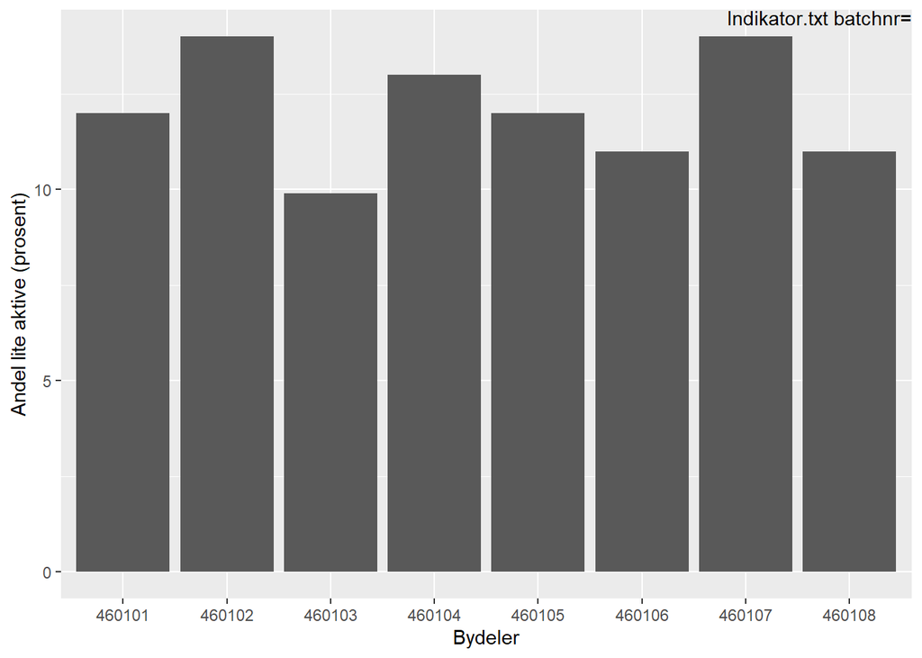

```r
# Dette funker.
# Når jeg legger på pipe og map() rundt ggplot, kræsjer det med en melding jeg ikke skjønner.
plotdata <- datasett %>%
  filter(LPnr == indik_nr, SpraakId == "BOKMAAL") %>%
  mutate(hjemmeby = str_sub(.$Sted_kode, start = 1, end = 2)) %>%
  # split(.$hjemmeby) %>%
  filter(hjemmeby == "46")

ggplot(plotdata, mapping = aes(x = Sted_kode, y = Verdi_lavesteGeonivaa)) +
        geom_col() +
        labs(x = "Bydeler", y = "Andel lite aktive (prosent)" ) +
        annotate(geom = "text", x = Inf, y = Inf, vjust = "inward", hjust = "inward",
                 label = "Indikator.txt batchnr=")
```